# 신한 퓨처 아카데미 2기 최종평가

- 제출 파일명은 이름_사번.ipynb파일로 제출해주세요.
- 문제에서 요구하는 내용을 반드시 출력해주세요. 코드만 있고 출력된 내용이 없으면 채점이 불가합니다.
- 제출 파일은 곽경일 강사에게 DM으로 제출해주세요.
- ChatGPT, 인터넷 검색은 불가하며, 교안 및 수업 때 진행했던 내용은 참고가 가능합니다.

## 1. 문제에 제시된 페이지에 있는 내용을 수집해서 아래와 같이 출력하세요.

(URL: https://wikidocs.net/book/5011)

- 전혀 구현하지 못했다. (0점)
- 구현했지만 출력 결과와 동일하지 않다. (15점)
- 완벽히 구현하였다. (25점)

|  | 제목 |
| --- | --- |
| 0 | Matplotlib Tutorial - 파이썬으로 데이터 시각화하기 |
| 1 | 00. Matplotlib 설치하기 |
| 2 | 01. Matplotlib 기본 사용 |
| 3 | 02. Matplotlib 숫자 입력하기 |
| 4 | 03. Matplotlib 축 레이블 설정하기 |
| 5 | 04. Matplotlib 범례 표시하기 |
| 6 | 05. Matplotlib 축 범위 지정하기 |
| 7 | 06. Matplotlib 선 종류 지정하기 |
| 8 | 07. Matplotlib 마커 지정하기 |
| 9 | 08. Matplotlib 색상 지정하기 |
| 10 | 09. Matplotlib 그래프 영역 채우기 |
| 11 | 10. Matplotlib 축 스케일 지정하기 |
| 12 | 11. Matplotlib 여러 곡선 그리기 |
| 13 | 12. Matplotlib 그리드 설정하기 |
| 14 | 13. Matplotlib 눈금 표시하기 |
| 15 | 14. Matplotlib 타이틀 설정하기 |
| 16 | 15. Matplotlib 수평선/수직선 표시하기 |
| 17 | 16. Matplotlib 막대 그래프 그리기 |
| 18 | 17. Matplotlib 수평 막대 그래프 그리기 |
| 19 | 18. Matplotlib 산점도 그리기 |
| 20 | 19. Matplotlib 3차원 산점도 그리기 |
| 21 | 20. Matplotlib 히스토그램 그리기 |
| 22 | 21. Matplotlib 에러바 표시하기 |
| 23 | 22. Matplotlib 파이 차트 그리기 |
| 24 | 23. Matplotlib 히트맵 그리기 |
| 25 | 24. Matplotlib 여러 개의 그래프 그리기 |
| 26 | 25. Matplotlib 컬러맵 설정하기 |
| 27 | 26. Matplotlib 텍스트 삽입하기 |
| 28 | 27. Matplotlib 수학적 표현 사용하기 |
| 29 | 28. Matplotlib 그래프 스타일 설정하기 |
| 30 | 29. Matplotlib 이미지 저장하기 |
| 31 | 30. Matplotlib 객체 지향 인터페이스 1 |
| 32 | 31. Matplotlib 객체 지향 인터페이스 2 |
| 33 | 32. Matplotlib 축 위치 조절하기 |
| 34 | 33. Matplotlib 이중 Y축 표시하기 |
| 35 | 34. Matplotlib 두 종류의 그래프 그리기 |
| 36 | 35. Matplotlib 박스 플롯 그리기 |
| 37 | 36. Matplotlib 바이올린 플롯 그리기 |
| 38 | 37. Matplotlib 다양한 도형 삽입하기 |
| 39 | 38. Matplotlib 다양한 패턴 채우기 |

```python
# 웹 크롤링 (Web Crawling) - BeautifulSoup
import requests
from bs4 import BeautifulSoup
import pandas as pd

# 웹 페이지 가져오기
url="https://wikidocs.net/book/5011"
response = requests.get(url)
html_content = response.content

# BeautifulSoup으로 HTML 파싱
soup = BeautifulSoup(html_content, "html.parser")
```

```python
list_group = soup.find("div", {'class': "list-group list-group-toc"})
list_items = list_group.find_all("a", {'class': "list-group-item"})

list = []
for list_item in list_items:
    list.append(list_item.text.strip())
df = pd.DataFrame(list)
df = df[:-1]
df["제목"] = df[0]

result = pd.DataFrame(df["제목"])
result
```

|  | 제목 |
| --- | --- |
| 0 | Matplotlib Tutorial - 파이썬으로 데이터 시각화하기 |
| 1 | 00. Matplotlib 설치하기 |
| 2 | 01. Matplotlib 기본 사용 |
| 3 | 02. Matplotlib 숫자 입력하기 |
| 4 | 03. Matplotlib 축 레이블 설정하기 |
| 5 | 04. Matplotlib 범례 표시하기 |
| 6 | 05. Matplotlib 축 범위 지정하기 |
| 7 | 06. Matplotlib 선 종류 지정하기 |
| 8 | 07. Matplotlib 마커 지정하기 |
| 9 | 08. Matplotlib 색상 지정하기 |
| 10 | 09. Matplotlib 그래프 영역 채우기 |
| 11 | 10. Matplotlib 축 스케일 지정하기 |
| 12 | 11. Matplotlib 여러 곡선 그리기 |
| 13 | 12. Matplotlib 그리드 설정하기 |
| 14 | 13. Matplotlib 눈금 표시하기 |
| 15 | 14. Matplotlib 타이틀 설정하기 |
| 16 | 15. Matplotlib 수평선/수직선 표시하기 |
| 17 | 16. Matplotlib 막대 그래프 그리기 |
| 18 | 17. Matplotlib 수평 막대 그래프 그리기 |
| 19 | 18. Matplotlib 산점도 그리기 |
| 20 | 19. Matplotlib 3차원 산점도 그리기 |
| 21 | 20. Matplotlib 히스토그램 그리기 |
| 22 | 21. Matplotlib 에러바 표시하기 |
| 23 | 22. Matplotlib 파이 차트 그리기 |
| 24 | 23. Matplotlib 히트맵 그리기 |
| 25 | 24. Matplotlib 여러 개의 그래프 그리기 |
| 26 | 25. Matplotlib 컬러맵 설정하기 |
| 27 | 26. Matplotlib 텍스트 삽입하기 |
| 28 | 27. Matplotlib 수학적 표현 사용하기 |
| 29 | 28. Matplotlib 그래프 스타일 설정하기 |
| 30 | 29. Matplotlib 이미지 저장하기 |
| 31 | 30. Matplotlib 객체 지향 인터페이스 1 |
| 32 | 31. Matplotlib 객체 지향 인터페이스 2 |
| 33 | 32. Matplotlib 축 위치 조절하기 |
| 34 | 33. Matplotlib 이중 Y축 표시하기 |
| 35 | 34. Matplotlib 두 종류의 그래프 그리기 |
| 36 | 35. Matplotlib 박스 플롯 그리기 |
| 37 | 36. Matplotlib 바이올린 플롯 그리기 |
| 38 | 37. Matplotlib 다양한 도형 삽입하기 |
| 39 | 38. Matplotlib 다양한 패턴 채우기 |

## 2. wine을 분류하는 머신러닝 모델을 만들고 학습한 뒤, 성능을 평가하고 모델을 해석하세요.

- 데이터 분할을 75:25 비율로 하세요.
- 데이터 표준화를 수행하세요.
- K 최근접 이웃 모델, 랜덤포레스트, XGBoost 모델을 만들고 어떤 모델이 성능이 더 좋은지 확인 후 제일 좋은 모델과 그 이유를 주석에 적어주세요.
- 모델의 성능 평가는 정확도, 정밀도, 재현율을 통해서 해석하세요.
- 하이퍼파라미터는 모두 기본값으로 설정하세요.

### wine 데이터 특성 설명

이 데이터는 와인 품질 분석을 위한 데이터입니다.

```
* alcohol: 와인의 알코올 함량
* malic_acid: 말산 함량
* ash: 재의 양(와인을 증발시킨 후 남은 고형물의 양)
* alcalinity_of_ash: 재의 알칼리도
* magnesium: 마그네슘 함량
* total_phenols: 총 페놀 함량
* flavanoids: 플라보노이드 함량
* nonflavanoid_phenols: 비플라보노이드 페놀 함량
* proanthocyanins: 프로안토시아니딘 함량
* color_intensity: 색의 강도
* hue: 색조
* od280/od315_of_diluted_wines: 희석된 와인의 흡광도 비율
* proline: 프롤린 함량
* target: 목표 변수
```

- 전혀 구현하지 못했다. (0점)
- 완벽히 모델들을 구현하지 못하였거나 해석이 부정확하다. (15점)
- 완벽히 모델들을 구현하고 정확하게 해석하였다. (25점)

```python
from sklearn.datasets import load_wine
import pandas as pd

wine = load_wine()

data = wine.data
target = wine.target

wine = pd.DataFrame(data, columns = wine['feature_names'])
wine['target'] = target
wine
```

|  | alcohol | malic_acid | ash | alcalinity_of_ash | magnesium | total_phenols | flavanoids | nonflavanoid_phenols | proanthocyanins | color_intensity | hue | od280/od315_of_diluted_wines | proline | target |
| --- | --- | --- | --- | --- | --- | --- | --- | --- | --- | --- | --- | --- | --- | --- |
| 0 | 14.23 | 1.71 | 2.43 | 15.6 | 127.0 | 2.80 | 3.06 | 0.28 | 2.29 | 5.64 | 1.04 | 3.92 | 1065.0 | 0 |
| 1 | 13.20 | 1.78 | 2.14 | 11.2 | 100.0 | 2.65 | 2.76 | 0.26 | 1.28 | 4.38 | 1.05 | 3.40 | 1050.0 | 0 |
| 2 | 13.16 | 2.36 | 2.67 | 18.6 | 101.0 | 2.80 | 3.24 | 0.30 | 2.81 | 5.68 | 1.03 | 3.17 | 1185.0 | 0 |
| 3 | 14.37 | 1.95 | 2.50 | 16.8 | 113.0 | 3.85 | 3.49 | 0.24 | 2.18 | 7.80 | 0.86 | 3.45 | 1480.0 | 0 |
| 4 | 13.24 | 2.59 | 2.87 | 21.0 | 118.0 | 2.80 | 2.69 | 0.39 | 1.82 | 4.32 | 1.04 | 2.93 | 735.0 | 0 |
| ... | ... | ... | ... | ... | ... | ... | ... | ... | ... | ... | ... | ... | ... | ... |
| 173 | 13.71 | 5.65 | 2.45 | 20.5 | 95.0 | 1.68 | 0.61 | 0.52 | 1.06 | 7.70 | 0.64 | 1.74 | 740.0 | 2 |
| 174 | 13.40 | 3.91 | 2.48 | 23.0 | 102.0 | 1.80 | 0.75 | 0.43 | 1.41 | 7.30 | 0.70 | 1.56 | 750.0 | 2 |
| 175 | 13.27 | 4.28 | 2.26 | 20.0 | 120.0 | 1.59 | 0.69 | 0.43 | 1.35 | 10.20 | 0.59 | 1.56 | 835.0 | 2 |
| 176 | 13.17 | 2.59 | 2.37 | 20.0 | 120.0 | 1.65 | 0.68 | 0.53 | 1.46 | 9.30 | 0.60 | 1.62 | 840.0 | 2 |
| 177 | 14.13 | 4.10 | 2.74 | 24.5 | 96.0 | 2.05 | 0.76 | 0.56 | 1.35 | 9.20 | 0.61 | 1.60 | 560.0 | 2 |

178 rows × 14 columns

```python
import pandas as pd
import numpy as np
import matplotlib.pyplot as plt
import seaborn as sns
from sklearn.model_selection import train_test_split, GridSearchCV
from sklearn.preprocessing import StandardScaler
from sklearn.metrics import r2_score, accuracy_score, classification_report, confusion_matrix, roc_auc_score, roc_curve, mean_squared_error, mean_absolute_error
from sklearn.linear_model import LogisticRegression, LinearRegression
from sklearn.neighbors import KNeighborsClassifier, KNeighborsRegressor
from sklearn.tree import DecisionTreeClassifier
from sklearn.ensemble import RandomForestClassifier,RandomForestRegressor
from sklearn.inspection import permutation_importance
from xgboost import XGBClassifier, plot_importance
```

```python
"""
* alcohol: 와인의 알코올 함량
* malic_acid: 말산 함량
* ash: 재의 양(와인을 증발시킨 후 남은 고형물의 양)
* alcalinity_of_ash: 재의 알칼리도
* magnesium: 마그네슘 함량
* total_phenols: 총 페놀 함량
* flavanoids: 플라보노이드 함량
* nonflavanoid_phenols: 비플라보노이드 페놀 함량
* proanthocyanins: 프로안토시아니딘 함량
* color_intensity: 색의 강도
* hue: 색조
* od280/od315_of_diluted_wines: 희석된 와인의 흡광도 비율
* proline: 프롤린 함량
* target: 목표 변수
"""

# 분할 및 표준화
wine = wine.dropna()

# 특성과 타겟 분리
X = wine.drop('target', axis=1).values
y = wine['target'].values

# 데이터 분할
X_train, X_test, y_train, y_test = train_test_split(X, y, test_size=0.25, random_state=42)

# 데이터 스케일링
scaler = StandardScaler()
X_train_scaled = scaler.fit_transform(X_train)
X_test_scaled = scaler.transform(X_test)
```

```
KNN score: 0.9555555555555556
KNN Accuracy: 0.9555555555555556
              precision    recall  f1-score   support

           0       0.94      1.00      0.97        15
           1       1.00      0.89      0.94        18
           2       0.92      1.00      0.96        12

    accuracy                           0.96        45
   macro avg       0.95      0.96      0.96        45
weighted avg       0.96      0.96      0.96        45
```

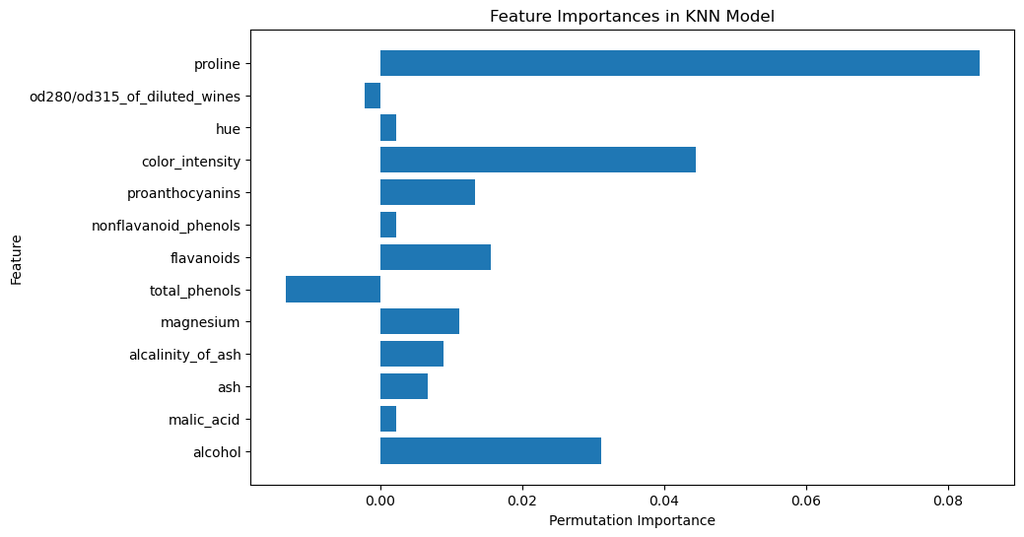

```python
#### K 근접 이웃모델
knn = KNeighborsClassifier(n_neighbors=3)
knn.fit(X_train_scaled, y_train)
knn.score(X_test_scaled, y_test)
y_pred = knn.predict(X_test_scaled)
accuracy = accuracy_score(y_test, y_pred)
print(f"KNN score: {knn.score(X_test_scaled, y_test)}")
print(f"KNN Accuracy: {accuracy}")

#정확도, 정밀도, 재현율
print(classification_report(y_test, y_pred))

# 특성 중요도 시각화 - KNN
features = wine.drop('target', axis=1).columns.tolist()
result_knn = permutation_importance(knn, X_test_scaled, y_test, n_repeats=10, random_state=42, n_jobs=2)
plt.figure(figsize=(10, 6))
plt.barh(features, result_knn.importances_mean)
plt.xlabel('Permutation Importance')
plt.ylabel('Feature')
plt.title('Feature Importances in KNN Model')
plt.show()
```

```
Random Forest Accuracy: 1.0
              precision    recall  f1-score   support

           0       1.00      1.00      1.00        15
           1       1.00      1.00      1.00        18
           2       1.00      1.00      1.00        12

    accuracy                           1.00        45
   macro avg       1.00      1.00      1.00        45
weighted avg       1.00      1.00      1.00        45
```

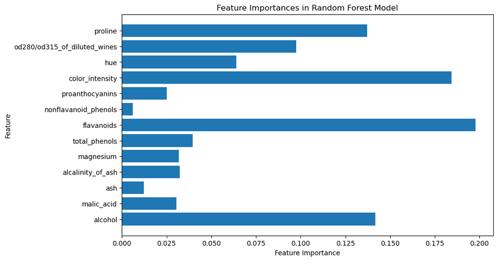

```python
#### 랜덤포레스트
rf = RandomForestClassifier(n_estimators=100, random_state=42, oob_score=True)
rf.fit(X_train, y_train) # 스케일링 필요없음
rf.oob_score_
y_pred = rf.predict(X_test)
accuracy = accuracy_score(y_test, y_pred)
print(f"Random Forest Accuracy: {accuracy}")

#정확도, 정밀도, 재현율
print(classification_report(y_test, y_pred))

# 중요 특징 시각화
feature_importances = rf.feature_importances_
features = wine.drop('target', axis=1).columns.tolist()
plt.figure(figsize=(10, 6))
plt.barh(features, feature_importances)
plt.xlabel('Feature Importance')
plt.ylabel('Feature')
plt.title('Feature Importances in Random Forest Model')
plt.show()
```

```
XGBoost Accuracy: 0.9333333333333333
              precision    recall  f1-score   support

           0       0.88      1.00      0.94        15
           1       0.94      0.89      0.91        18
           2       1.00      0.92      0.96        12

    accuracy                           0.93        45
   macro avg       0.94      0.94      0.94        45
weighted avg       0.94      0.93      0.93        45
```

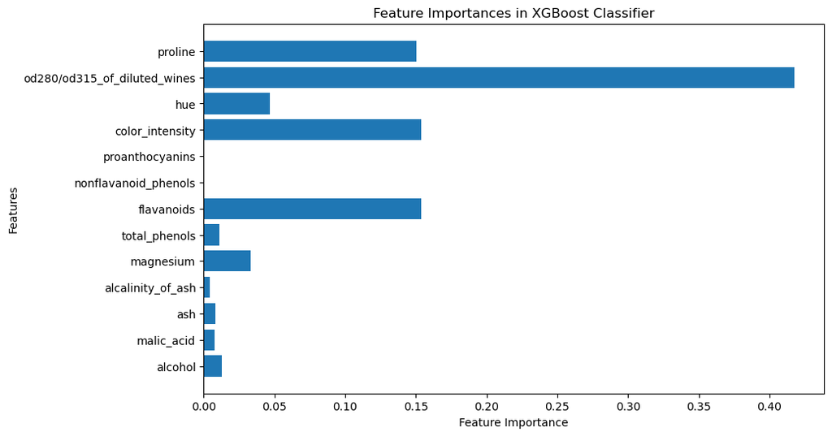

```python
#### XGBoost
# XGBoost 분류기 모델 정의 및 학습
from xgboost import XGBClassifier
xgb = XGBClassifier(random_state=42)
xgb.fit(X_train, y_train)
y_pred = xgb.predict(X_test)
accuracy = accuracy_score(y_test, y_pred)
print(f"XGBoost Accuracy: {accuracy}")

#정확도, 정밀도, 재현율
print(classification_report(y_test, y_pred))

# 특성 중요도 시각화
feature_importances = xgb.feature_importances_
features = wine.drop('target', axis=1).columns.tolist()

plt.figure(figsize=(10, 6))
plt.barh(features, feature_importances)
plt.xlabel('Feature Importance')
plt.ylabel('Features')
plt.title('Feature Importances in XGBoost Classifier')
plt.show()
```

```python
################# 결론 #################
# K 최근접 이웃 모델, 랜덤포레스트, XGBoost 모델을 만들고 어떤 모델이 성능이 더 좋은지 확인 후 제일 좋은 모델과 그 이유를 주석에 적어주세요.
# 모델의 성능 평가는 정확도, 정밀도, 재현율을 통해서 해석하세요.

# Knn, rf, xgboost 중 가장 성능과 정확도가 높은 것은 rf(랜덤포레스트)였습니다.
# 성능평가 지표룰 보면 알수있다시피,rf의 정확도, 정밀도, 재현율, f1score 모두 1.0으로 100% 만족했고,
# feature importances도 적절하게 분류하였습니다.
#######################################
```

## 3. 캘리포니아 주택 가격 회귀 예측하는 머신러닝 모델을 만들고 학습한 뒤, 성능을 평가하고 모델을 해석하세요.

- 데이터 분할을 9:1 비율로 하세요.
- 데이터 표준화를 수행하세요.
- K 최근접 이웃 모델, 랜덤포레스트 모델, 선형 회귀 모델을 만들고 어떤 모델이 성능이 더 좋은지 확인 후 제일 좋은 모델과 그 이유를 주석에 적어주세요.
- 성능평가는 MAE, RMSE, MSE, R^2 값을 통해서 해석하세요.
- 하이퍼파라미터는 모두 기본값으로 설정하세요.

### 캘리포니아 주택 가격 데이터 특성 설명

이 데이터셋은 캘리포니아 주택 가격 예측을 위한 데이터셋 입니다.

```
* MedInc: Median Income. 각 지역(블록 그룹)의 중간 소득
* HouseAge: House Age. 각 지역의 주택의 중간 연령
* AveRooms: Average Rooms. 각 주택당 평균 방 개수
* AveBedrms: Average Bedrooms. 각 주택당 평균 침실 개수
* Population: Population. 각 지역의 인구 수
* AveOccup: Average Occupancy. 각 주택당 평균 거주자 수
* Latitude: Latitude. 각 지역의 위도 정보
* Longitude: Longitude. 각 지역의 경도 정보
* target: Target. 타겟 변수로, 각 지역의 주택 가격의 중간값
```

- 전혀 구현하지 못했다. (0점)
- 완벽히 모델들을 구현하지 못하였거나 해석이 부정확하다. (15점)
- 완벽히 모델들을 구현하고 정확하게 해석하였다. (25점)

```python
from sklearn.datasets import fetch_california_housing

california = fetch_california_housing()

data = california.data
target = california.target

california = pd.DataFrame(data, columns = california['feature_names'])
california['target'] = target
california
```

|  | MedInc | HouseAge | AveRooms | AveBedrms | Population | AveOccup | Latitude | Longitude | target |
| --- | --- | --- | --- | --- | --- | --- | --- | --- | --- |
| 0 | 8.3252 | 41.0 | 6.984127 | 1.023810 | 322.0 | 2.555556 | 37.88 | -122.23 | 4.526 |
| 1 | 8.3014 | 21.0 | 6.238137 | 0.971880 | 2401.0 | 2.109842 | 37.86 | -122.22 | 3.585 |
| 2 | 7.2574 | 52.0 | 8.288136 | 1.073446 | 496.0 | 2.802260 | 37.85 | -122.24 | 3.521 |
| 3 | 5.6431 | 52.0 | 5.817352 | 1.073059 | 558.0 | 2.547945 | 37.85 | -122.25 | 3.413 |
| 4 | 3.8462 | 52.0 | 6.281853 | 1.081081 | 565.0 | 2.181467 | 37.85 | -122.25 | 3.422 |
| ... | ... | ... | ... | ... | ... | ... | ... | ... | ... |
| 20635 | 1.5603 | 25.0 | 5.045455 | 1.133333 | 845.0 | 2.560606 | 39.48 | -121.09 | 0.781 |
| 20636 | 2.5568 | 18.0 | 6.114035 | 1.315789 | 356.0 | 3.122807 | 39.49 | -121.21 | 0.771 |
| 20637 | 1.7000 | 17.0 | 5.205543 | 1.120092 | 1007.0 | 2.325635 | 39.43 | -121.22 | 0.923 |
| 20638 | 1.8672 | 18.0 | 5.329513 | 1.171920 | 741.0 | 2.123209 | 39.43 | -121.32 | 0.847 |
| 20639 | 2.3886 | 16.0 | 5.254717 | 1.162264 | 1387.0 | 2.616981 | 39.37 | -121.24 | 0.894 |

20640 rows × 9 columns

```python
# 데이터 분할 및 표준화
# 특성과 타겟 분리
X = california.drop('target', axis=1).values
y = california['target'].values

# 데이터 분할
X_train, X_test, y_train, y_test = train_test_split(X, y, test_size=0.1, random_state=42)

# 데이터 스케일링
scaler = StandardScaler()
X_train_scaled = scaler.fit_transform(X_train)
X_test_scaled = scaler.transform(X_test)
```

```
knr_mae: 0.45482982396640825
knr_rmse: 0.680388198274335
knr_mse: 0.46292810035099585
knr_r2: 0.6528757856578455
```

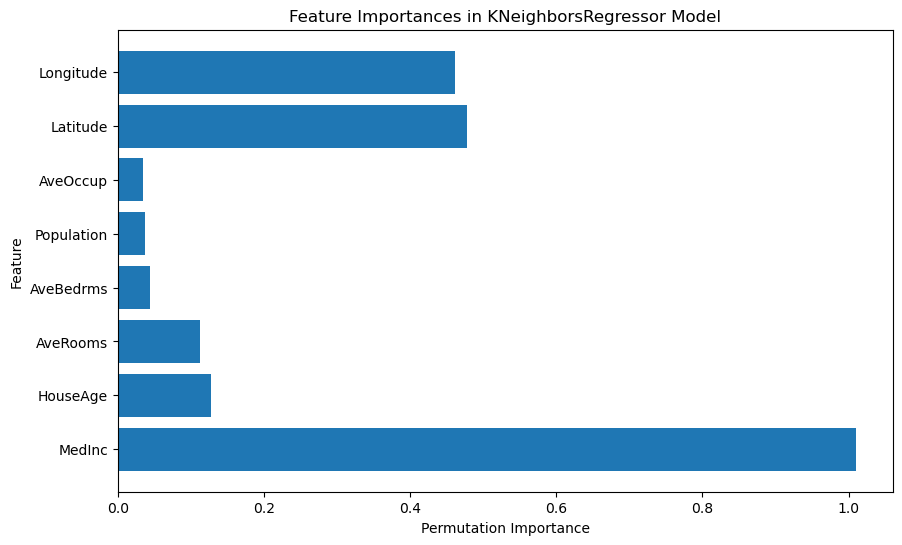

```python
# K 근접 이웃 모델
knr = KNeighborsRegressor(n_neighbors=3)
knr.fit(X_train_scaled, y_train)
knr.score(X_test_scaled, y_test)
y_pred = knr.predict(X_test_scaled)

# MAE, RMSE, MSE, R^2 값
knr_mae = mean_absolute_error(y_test, y_pred)
knr_rmse = np.sqrt(mean_squared_error(y_test, y_pred))
knr_mse = mean_squared_error(y_test, y_pred)
knr_r2 = r2_score(y_test, y_pred)

print(f"knr_mae: {knr_mae}")
print(f"knr_rmse: {knr_rmse}")
print(f"knr_mse: {knr_mse}")
print(f"knr_r2: {knr_r2}")

# 특성 중요도 시각화 - KNR
result_knr = permutation_importance(knr, X_test_scaled, y_test, n_repeats=10, random_state=42, n_jobs=2)
plt.figure(figsize=(10, 6))
plt.barh(features, result_knr.importances_mean)
plt.xlabel('Permutation Importance')
plt.ylabel('Feature')
plt.title('Feature Importances in KNeighborsRegressor Model')
plt.show()
```

```
rfr_mae: 0.32430728561046523
rfr_rmse: 0.5050667344997503
rfr_mse: 0.2550924062982412
rfr_r2: 0.8087202935968064
```

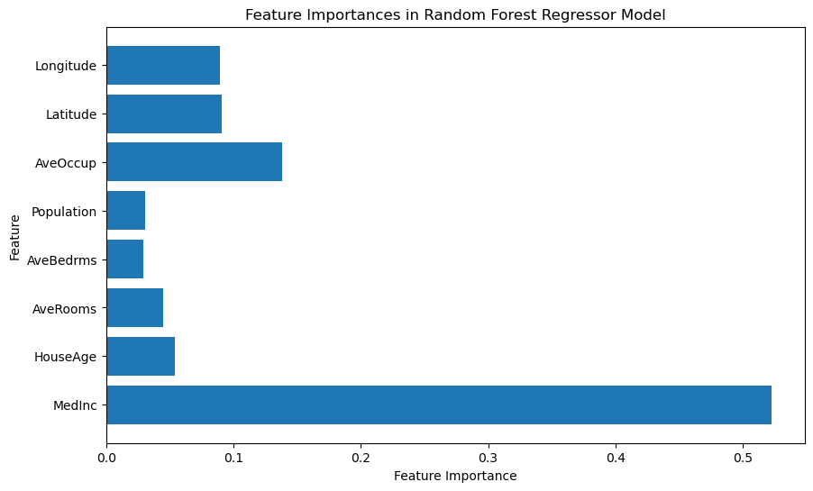

```python
# 랜덤포레스트 모델
rfr = RandomForestRegressor(n_estimators=100, random_state=42, oob_score=True)
rfr.fit(X_train, y_train) # 스케일링 필요없음
rfr.oob_score_
y_pred = rfr.predict(X_test)

# MAE, RMSE, MSE, R^2 값
rfr_mae = mean_absolute_error(y_test, y_pred)
rfr_rmse = np.sqrt(mean_squared_error(y_test, y_pred))
rfr_mse = mean_squared_error(y_test, y_pred)
rfr_r2 = r2_score(y_test, y_pred)

print(f"rfr_mae: {rfr_mae}")
print(f"rfr_rmse: {rfr_rmse}")
print(f"rfr_mse: {rfr_mse}")
print(f"rfr_r2: {rfr_r2}")

# 중요 특징 시각화
feature_importances = rfr.feature_importances_
features = california.drop('target', axis=1).columns.tolist()
plt.figure(figsize=(10, 6))
plt.barh(features, feature_importances)
plt.xlabel('Feature Importance')
plt.ylabel('Feature')
plt.title('Feature Importances in Random Forest Regressor Model')
plt.show()
```

```
lr_mae: 0.5423972782283893
lr_rmse: 0.747664312711636
lr_mse: 0.5590019245025631
lr_r2: 0.5808353312067694
```

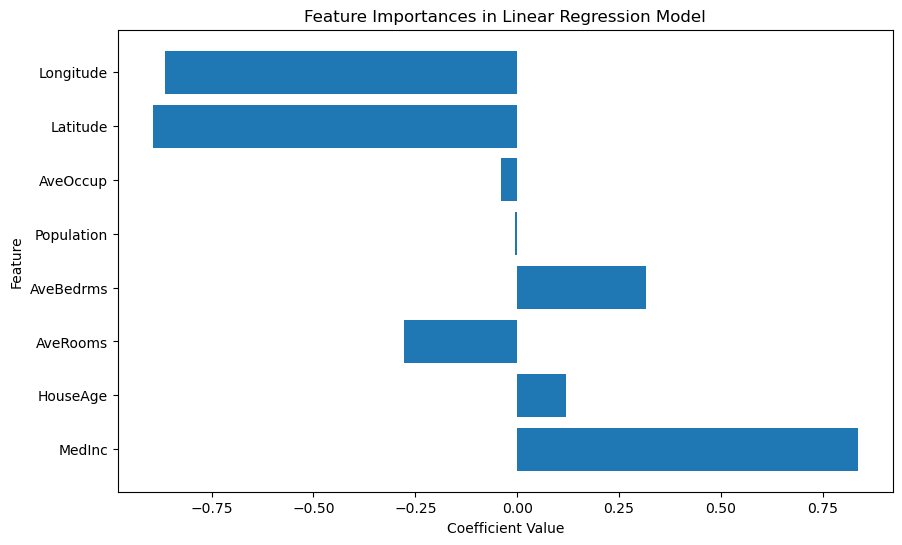

```python
# 선형회귀모델
lr = LinearRegression()
lr.fit(X_train_scaled, y_train)
y_pred = lr.predict(X_test_scaled)

# MAE, RMSE, MSE, R^2 값
lr_mae = mean_absolute_error(y_test, y_pred)
lr_rmse = np.sqrt(mean_squared_error(y_test, y_pred))
lr_mse = mean_squared_error(y_test, y_pred)
lr_r2 = r2_score(y_test, y_pred)

print(f"lr_mae: {lr_mae}")
print(f"lr_rmse: {lr_rmse}")
print(f"lr_mse: {lr_mse}")
print(f"lr_r2: {lr_r2}")

# 특성 중요도 시각화 - LinearRegression
coefficients = lr.coef_
plt.figure(figsize=(10, 6))
plt.barh(features, coefficients)
plt.xlabel('Coefficient Value')
plt.ylabel('Feature')
plt.title('Feature Importances in Linear Regression Model')
plt.show()
```

```python
################# 결론 #################
# K 최근접 이웃 모델, 랜덤포레스트 모델, 선형 회귀 모델을 만들고 어떤 모델이 성능이 더 좋은지 확인 후 제일 좋은 모델과 그 이유를 주석에 적어주세요.
# 성능평가는 MAE, RMSE, MSE, R^2 값을 통해서 해석하세요.

# Knr, rfr, lr 중 가장 성능과 정확도(r2:설명력, mae&rmse:오차)가 높은 것은 rfr(랜덤포레스트)였습니다.
# 성능평가 지표룰 보면 알수있다시피,rf의 mae, rmse, mse, r2를 볼 때 가장 좋은 값으로 만족했고,
# feature importances도 적절하게 분류하였습니다.
#######################################
```

## 4. iris 데이터의 최적의 군집이 몇 개인지 구하세요.

KMeans 알고리즘을 사용해서 최적의 군집이 몇 개인지 구하고 그 이유를 주석으로 적어주세요.

- 전혀 구현하지 못했다. (0점)
- 완벽히 현하지 못하였거나 해석이 부정확하다. (15점)
- 완벽히 구현하고 정확하게 해석하였다. (25점)

```python
from sklearn.datasets import load_iris

iris = load_iris()
iris = pd.DataFrame(iris.data, columns = iris['feature_names'])
iris
```

|  | sepal length (cm) | sepal width (cm) | petal length (cm) | petal width (cm) |
| --- | --- | --- | --- | --- |
| 0 | 5.1 | 3.5 | 1.4 | 0.2 |
| 1 | 4.9 | 3.0 | 1.4 | 0.2 |
| 2 | 4.7 | 3.2 | 1.3 | 0.2 |
| 3 | 4.6 | 3.1 | 1.5 | 0.2 |
| 4 | 5.0 | 3.6 | 1.4 | 0.2 |
| ... | ... | ... | ... | ... |
| 145 | 6.7 | 3.0 | 5.2 | 2.3 |
| 146 | 6.3 | 2.5 | 5.0 | 1.9 |
| 147 | 6.5 | 3.0 | 5.2 | 2.0 |
| 148 | 6.2 | 3.4 | 5.4 | 2.3 |
| 149 | 5.9 | 3.0 | 5.1 | 1.8 |

150 rows × 4 columns

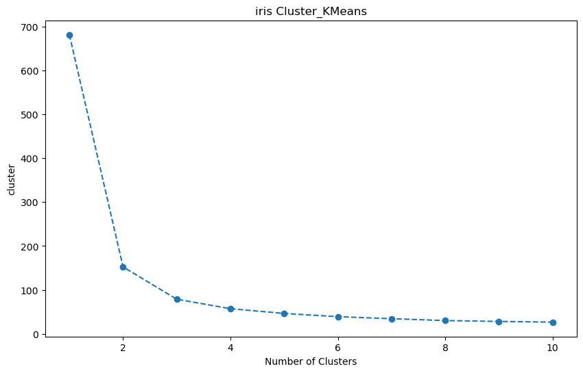

```python
import pandas as pd
from sklearn.datasets import load_iris
from sklearn.cluster import KMeans
import matplotlib.pyplot as plt

# Iris 데이터 로드
iris = load_iris()
X = iris.data

# 군집계산을 위한 빈 리스트
cluster = []

# 군집 수를 1에서 10까지 변화시키면서 KMeans 알고리즘을 적용
for i in range(1, 11):
    kmeans = KMeans(n_clusters=i, init='k-means++', max_iter=300, n_init=10, random_state=42)
    kmeans.fit(X)
    cluster.append(kmeans.inertia_)  # 값을 리스트에 추가

# 군집 값을 그래프로 시각화하여 가장 꺾이는 점 찾기
plt.figure(figsize=(10, 6))
plt.plot(range(1, 11), cluster, marker='o', linestyle='--')
plt.title('iris Cluster_KMeans')
plt.xlabel('Number of Clusters')
plt.ylabel('cluster')
plt.show()
```

```python
################# 결론 #################
# KMeans 알고리즘을 사용해서 iris 데이터의 최적의 군집이 몇 개인지 구하는 코드를 작성하고 그 이유를 주석으로 적어주세요.

# KMeans를 통해 군집 내 군집 중심 간의 거리를 구했습니다.
# for 1~10까지 n_cluster를 변화하면서 적용했고,
# 2~3에서 가장 많이 그래프가 꺾이는 것을 볼 수 있습니다.
# 따라서, 군집은 2~3개 사이이며, 이 중 군집이 제일 많이 꺾이게 되었다가 완만해지는 쪽이 그래프가 값 중 3이므로, 약 3개의 군집을 가지고 있음을 알 수 있습니다.
#######################################
```